# Dealing with Limited Dependent Variable Output

The following functions offer a quick way to cleanly visualize the predicted probabilities, marginal effects, and discrete differences from binary dependent variable models calculated using either `R2jags` or `R2WinBUGS` or `R2OpenBUGS`.[^1]

It should be noted upfront that this process doesn’t simulate the data to produce the confidence intervals, but rather utilizes the observed value approach (see Hanmer & Kalkan 2013). In short, the functions use the *actual* data to calculate the standard errors rather than some generalized observation (composed solely of means, medians, and modes) to generate the simulated data.

Here I will outline what each function can do by offering a quick example using `R2jags` output compiled from observed data.

# Functions

- `pprobs()`
- `marginFX()`
- `diffFX()`

## Predicted Probabilities

Here there are two options of graphical representation:

The **smoother**

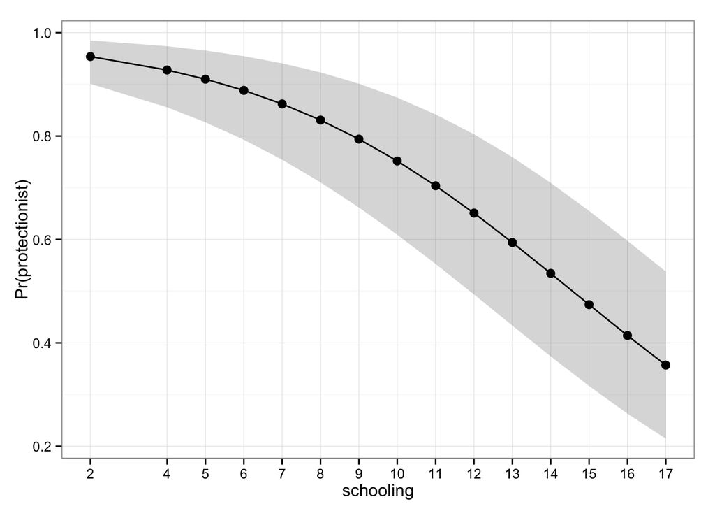

```r
pprobs(mcmc.output = fit, model.data = jags.data,params = c("alpha","b"),
       manipulation.var = "schooling",dv="protectionist",type = "smoother",points = T)
```

And the **discrete** options.

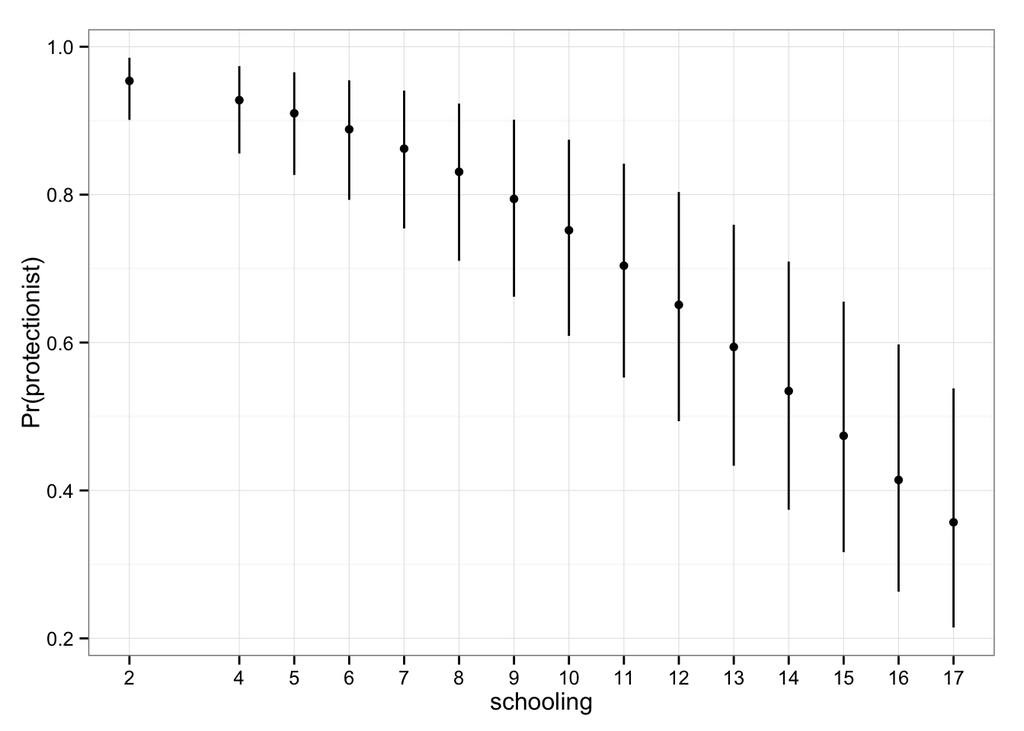

```r
pprobs(mcmc.output = fit, model.data = jags.data,params = c("alpha","b"),
       manipulation.var = "schooling",dv="protectionist",type = "discrete",points = T)
```

> Note: It is essential that the parameters are ordered as they appear in the model (i.e. alpha + b[1] + b[2] … etc.). Failure to do so will lead to some “really messed up” output. In addition, be sure to feed in the data that used to run the rjags/winBugs model.

## Marginal Effects

Calculate the marginal effects given the base probability of the IV of interests on the DV.

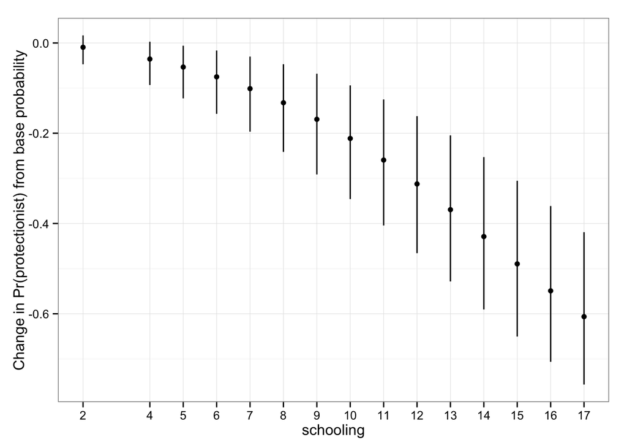

```r
marginFX(mcmc.output = fit,model.data = jags.data,params = c("alpha","b"),
         manipulation.var = "schooling",dv="protectionist",type = "discrete",points = T)
```

Again there is a “discrete” and “smoother” option here. Also, the points can be turned on or off on the “smoother” plot.

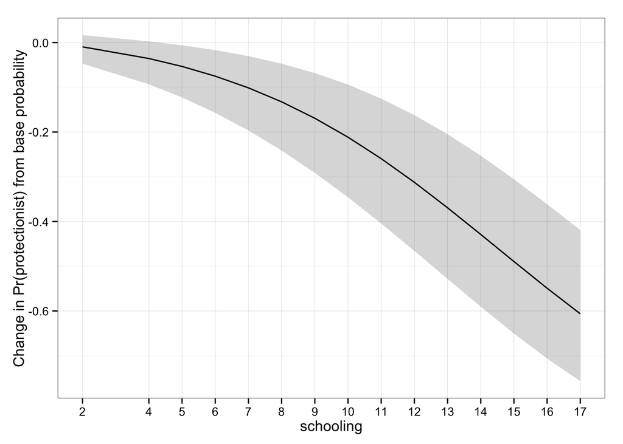

```r
marginFX(mcmc.output = fit,model.data = jags.data,params = c("alpha","b"),
         manipulation.var = "schooling",dv="protectionist",type = "smoother",points = F)
```

## Discrete Effects

Calculates the distribution of the discrete difference in the probability along a specified range. The output returns a distribution since it calculates the difference using the posterior distribution provided by the model.

The following will look at the discrete difference in the effect on the predicted probability when switching from male to female.

There are two settings to this function – **ci.distribution** which utilizes the vizualization features of the `hdrcde` package.

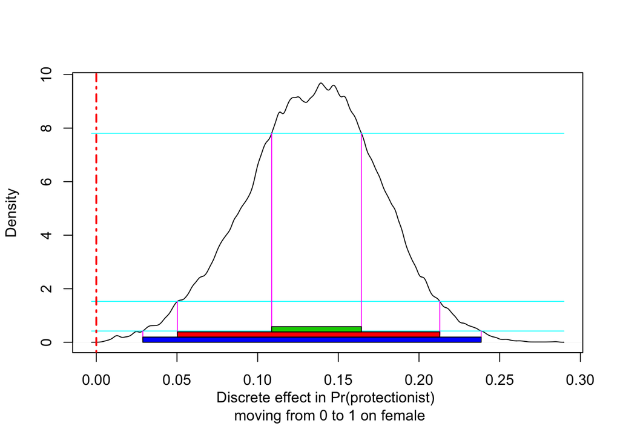

```r
diffFX(mcmc.output = fit,model.data = jags.data,params = c("alpha","b"),
       from = 0,to=1,manipulation.var ="female",dv="protectionist",type="ci.distribution")
```

and **distribution**, which offers a more simplified plot.

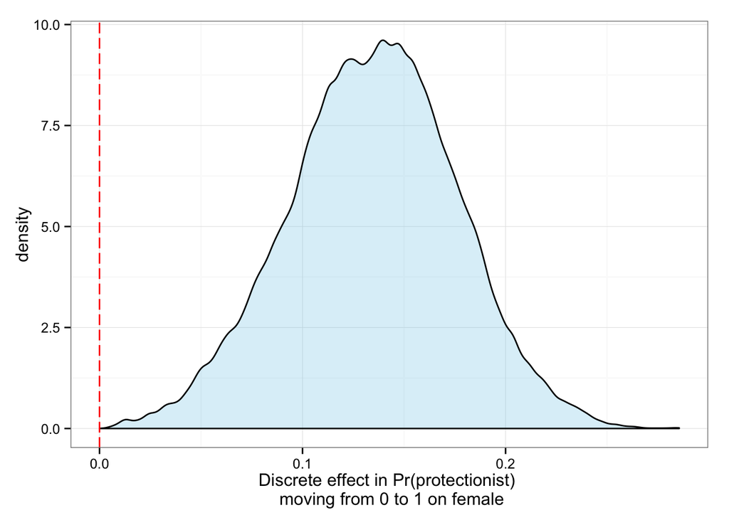

```r
diffFX(mcmc.output = fit,model.data = jags.data,params = c("alpha","b"),
       from = 0,to=1,manipulation.var ="female",dv="protectionist",type="distribution")
```

There are a lot of inputs to stay mindful of and many ways in which these functions can break…but for now, these offer a nice shortcut to visualizing the output of a binary dependent variable bayesian model.

Please feel free to email edunford@umd.edu if there are any issues/suggestions/comments. Also, I should note that these functions were constructed using output from `R2jags` so there may be some compatibility issues for the winBug users out there. Please let me know if there are, and I’ll fix them!

[^1]: Note there should be no issues when using rjags.